# Exercises part 2

Course: Data analysis and visualization using R

## Section 4. `apply` and its relatives

In this section you will encounter some exercises revolving around the different flavours of apply.

### **Exercise 4.1.**

On the course website, you will find file whale_selenium.txt. You could download it into your working directory manually or use `download.file()`, but you can also read it directly using `read.table()` as shown here.

```r
whale.selenium <- read.table(
    "https://raw.githubusercontent.com/MichielNoback/R_data_analysis_and_visualization/master/presentations/data/whale_selenium.txt",
    header = T,
    row.names = 1)
head(whale.selenium)
```

```
##   liver.Se tooth.Se
## 1     6.23   140.16
## 2     6.79   133.32
## 3     7.92   135.34
## 4     8.02   127.82
## 5     9.34   108.67
## 6    10.00   146.22
```

**(a)** Report the means of both columns using apply().

```r
apply(X = whale.selenium, MARGIN = 2, FUN = mean)
```

```
## liver.Se tooth.Se
##   20.685  156.599
```

**(b)** Report the standard deviation of both columns, again using apply.

```r
apply(X = whale.selenium, MARGIN = 2, FUN = sd)
```

```
## liver.Se tooth.Se
## 13.44911 36.05949
```

**(c)** Report the standard error of the mean of both columns, again using apply. The SEM is calculated as
$$\frac{s}{\sqrt{n}}$$
where $s$ is the sample standard deviation and $n$ the number of measurements. You should create the function calculating this statistic yourself.

```r
my.sem <- function(x) {
    sem <- sd(x) / sqrt(length(x))
}
apply(X = whale.selenium, MARGIN = 2, FUN = my.sem)
```

```
## liver.Se tooth.Se
## 3.007313 8.063148
```

**(d)** Using apply, calculate the ratio of $Se_{tooth} / Se_{liver}$ and attach it to the whale.selenium dataframe as column `ratio`. Create a histogram of this ratio.

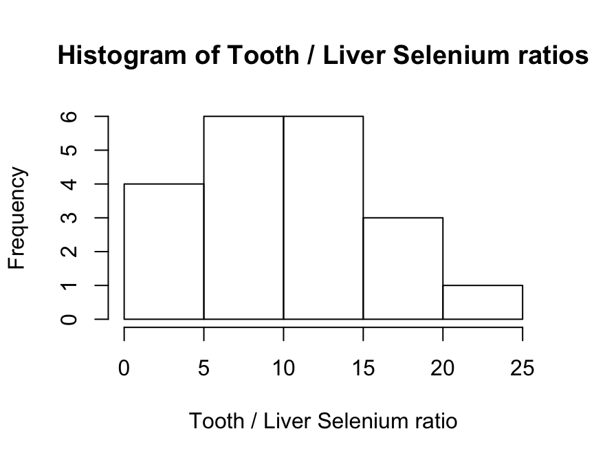

```r
whale.selenium$ratio <- apply(X = whale.selenium,
      MARGIN = 1,
      FUN = function(x){
          x[2] / x[1]
      })
hist(whale.selenium$ratio,
     xlab = "Tooth / Liver Selenium ratio",
     main = "Histogram of Tooth / Liver Selenium ratios")
```

**(e)** Using print and paste, report the mean and the standard deviation of the ratio column, but do this with an inline expression, e.g. an expression embedded in the Rmarkdown text.

**The mean of the ratios is 10.565436 and the standard deviation is 5.5871469**

### **Exercise 4.2.**

This exercise revolves around the `ChickWeight` dataset of the built-in `datasets` package.

**(a)** Use an R expression to report the number of chickens used in the experiment.

```r
#MANY WAYS TO GET THERE
length(split(ChickWeight, ChickWeight$Chick))
```

```
## [1] 50
```

```r
#OR
sum(tapply(ChickWeight$Diet, ChickWeight$Chick, FUN = function(x){1}))
```

```
## [1] 50
```

```r
#OR
length(unique(ChickWeight$Chick))
```

```
## [1] 50
```

```r
#OR
nrow(aggregate(x = ChickWeight, by = list(ChickWeight$Chick), FUN = function(x){x}))
```

```
## [1] 50
```

**(b)** Use `aggregate()` to get the mean weight of the chickens for the different Diets.

```r
aggregate(formula = weight ~ Diet, data=ChickWeight, FUN = mean, na.rm = T)
```

```
##   Diet   weight
## 1    1 102.6455
## 2    2 122.6167
## 3    3 142.9500
## 4    4 135.2627
```

```r
#OR
aggregate(x = ChickWeight$weight, by = list(Diet = ChickWeight$Diet), FUN = mean, na.rm = T)
```

```
##   Diet        x
## 1    1 102.6455
## 2    2 122.6167
## 3    3 142.9500
## 4    4 135.2627
```

**(c)** Use `coplot()` to plot a panel with weight as function of Time, split over Diet.

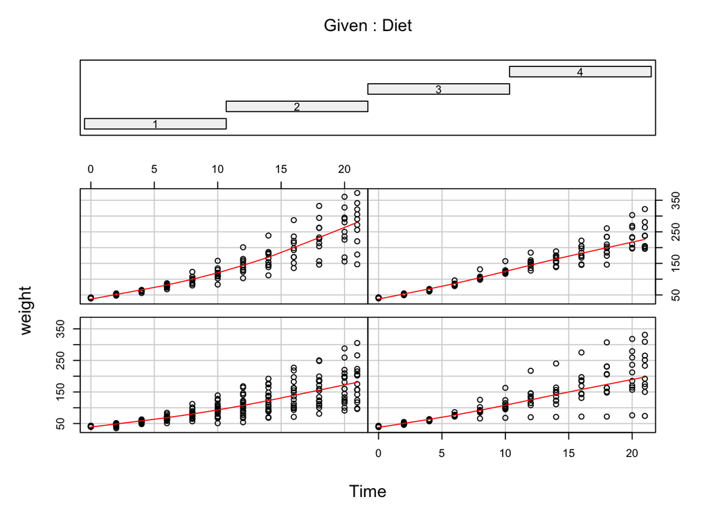

```r
coplot(weight ~ Time | Diet, data = ChickWeight, panel = panel.smooth)
```

**(d)**

Add a column called `weight.gain` to the dataframe holding values for the weight gain since the last measurement. Take special care with rows marking the boundaries between indivivdual chickens! You could consider using a traditional for loop here.

```r
#A naive for-loop here - is this the best solution?
ChickWeight$weight.gain <- NA #create the column with missing values
for (i in 1:nrow(ChickWeight)) {
    #skip first row and rows that are preceded by values for another chick
    if (i > 1 && ChickWeight$Chick[i] == ChickWeight$Chick[i-1]) {
        ChickWeight[i, "weight.gain"] <- ChickWeight$weight[i] - ChickWeight$weight[i-1]
    }
}
#stored.weight.gain <- ChickWeight$weight.gain
#save(stored.weight.gain, file = "./data/ChickWeight_weight_gain.Rdata")
```

**(e)**

Split the `weight.gain` column on Diet and report the mean, median and standard deviation for each diet. Note, if you were not succesful in the previous question, load and attach the data from file `ChickWeight_weight_gain.Rdata` downloadable from `https://github.com/MichielNoback/R_data_analysis_and_visualization/blob/master/exercises/data/ChickWeight_weight_gain.Rdata` (click on button “Raw” to download and use `load()` to load variable `stored.weight.gain`).

```r
tapply(X = ChickWeight$weight.gain, INDEX = ChickWeight$Diet, FUN = mean, na.rm = T)
```

```
##        1        2        3        4
## 11.49000 15.81818 20.86364 17.43519
```

```r
#or with aggregate
aggregate(formula = weight.gain ~ Diet, data = ChickWeight, FUN = median)
```

```
##   Diet weight.gain
## 1    1         9.0
## 2    2        13.0
## 3    3        19.5
## 4    4        17.0
```

```r
#or with split and sapply
sapply(split(ChickWeight[, "weight.gain"], ChickWeight$Diet), sd, na.rm = T)
```

```
##         1         2         3         4
##  9.390999 11.030551 12.713121 10.008663
```

**(f)**

Create a (single-panel) boxplot for weight gain, split over Diet. Hint: read the `boxplot()` help page!

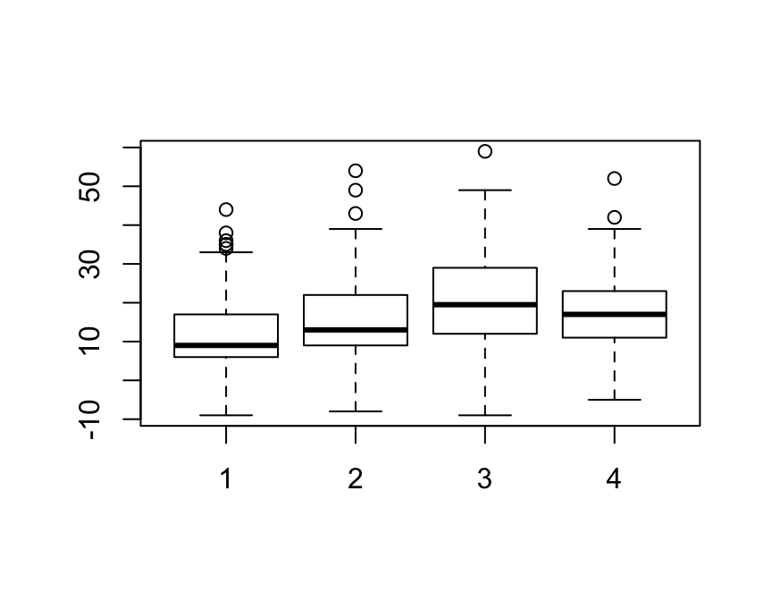

```r
boxplot(weight.gain ~ Diet, data = ChickWeight)
```